# NBA Per-36 Projection Pipeline (Steps 1–4)

# 1 Introduction

Basketball analytics has advanced beyond simple counting stats — today’s analysts use historical data and predictive modeling to forecast player performance and assess team-building strategy.

This project aims to **predict year-over-year changes in NBA player per-36-minute statistics** (PTS, REB, AST, STL, BLK, TOV, etc.) using several lightweight, interpretable modeling methods.

The central question: > *Which projection method best captures next-season player performance given up to five years of historical data?*

We evaluate three approaches: - **Equal weighting** (simple average) - **Exponential weighting** (recency emphasis) - **Linear regression** (trend-based prediction)

Each method is tested across major per-36 statistics using walk-forward validation, and model performance is compared using **relative Root Mean Squared Error (relRMSE)** — a normalized measure of prediction accuracy.

# 2 Data Source and Quality

All player data was sourced from **Kaggle** — specifically, the *NBA Player Stats Per 36 Minutes by Season* dataset.  
It holds a **10/10 usability rating**, reflecting: - Clean, well-documented column naming conventions, - Consistent formatting across seasons, - Comprehensive coverage of NBA players and key performance metrics.

Columns include: - `player`, `season`, `team`, `age`, `mp` (minutes) - Per-36-minute statistics (e.g., `pts_per_36_min`, `ast_per_36_min`, etc.)

Before modeling, the data is cleaned and merged to ensure that each player-season observation is unique and complete.

# 3 Problem Statement and Methodology

## 3.1 Objective

To determine **which projection method minimizes prediction error** for each player stat and to produce **next-season projections** for all qualifying players.

We define the problem as a **time-based regression** task:
$$\text{Predict Stat}_{t+1} = f(\text{Stat}_{t}, \text{Stat}_{t-1}, ...,
\text{Stat}_{t-k})$$
where $k$ is the lookback window (1–5 previous seasons).

## 3.2 Methods Compared

| Method | Description | Notes |
| --- | --- | --- |
| **Equal (EQUAL)** | Simple mean of last k seasons | Baseline |
| **Exponential (EXP)** | Weighted average giving more importance to recent years | Uses decay parameter α |
| **Linear (LM)** | Fitted linear regression over k seasons | Sensitive to data availability |

## 3.3 Evaluation Metric

The key metric is **relative RMSE (relRMSE)**:

$$\text{relRMSE} = \frac{RMSE}{SD(\text{actual})}$$

This allows for cross-stat comparisons by normalizing for each stat’s natural variability.

# 4 Data Preparation

The preprocessing stage ensures: - Minimum **minutes played threshold (1000)** for season inclusion, - Correct handling of multi-team years, - Rolling **lookback features (L1–L5)** built for each stat, - Filtering by season (2015 onward) to ensure modern consistency.

```r
# Fast, reproducible, and quiet setup
knitr::opts_chunk$set(
  echo = TRUE, message = FALSE, warning = FALSE,
  cache = TRUE, cache.comments = FALSE
)

suppressPackageStartupMessages({
  library(dplyr)
  library(readr)
  library(tidyr)
  library(stringr)
  library(purrr)
  library(broom)
  library(janitor)
  library(here)
  library(dplyr)
  library(ggplot2)
  library(ggrepel)
  library(scales)
  library(rlang)
  library(ggtext)
})

knitr::opts_knit$set(root.dir = here::here())

set.seed(1)

if (!exists("params")) {
params <- list(
per36_csv = "data/Per36Minutes.csv",
career_csv = "data/PlayerCareerInfo.csv"
)
}

stat_labs <- c(
pts_per_36_min = "PTS/36",
trb_per_36_min = "TRB/36",
ast_per_36_min = "AST/36",
stl_per_36_min = "STL/36",
blk_per_36_min = "BLK/36",
x3p_per_36_min = "3PM/36",
fg_percent = "FG%",
ft_percent = "FT%",
tov_per_36_min = "TOV/36"
)
```

# 5 Modeling Functions

Here, we define the helper functions used to:

- Filter player eligibility,
- Compute rolling averages,
- Evaluate predictive accuracy across methods.

Each function applies consistent cutoffs and validation rules to maintain fairness between methods.

```r
# Light helpers used in multiple chunks
wavg <- function(x, w) {
  s <- sum(w, na.rm = TRUE)
  ifelse(s > 0, sum(x * w, na.rm = TRUE) / s, NA_real_)
}

read_data <- function(rel_path) {
stopifnot(is.character(rel_path), length(rel_path) == 1)
fp <- here::here(rel_path)
if (!file.exists(fp)) stop("Missing data file: ", fp, call. = FALSE)
readr::read_csv(fp, show_col_types = FALSE)
}
```

# 6 Load & Robust Season Collapse

This step ingests the raw per-36 dataset and collapses multi-team stints into a single player-season row. It prefers explicit “TOT”/multi-team markers when available and falls back to a games-based heuristic if the team column is missing. Stats across stints are merged with minutes-weighted averages, and FG%/FT% are recomputed from made/attempt totals to avoid mixed denominators.

- Input: Per36Minutes.csv (cleaned to snake_case).
- Combined-row detection: use team/tm when present; else infer by comparing games.
- Minutes & games totals: trust the official combined row if its minutes ≈ sum of team stints (≥95%); otherwise use summed minutes.
- Minutes-weighted merge: PTS/36, TRB/36, AST/36, STL/36, BLK/36, 3PM/36, TOV/36, FGA/36, FTA/36.
- Recomputed percentages: FG% = FGM / FGA, FT% = FTM / FTA from stint-level totals.
- Metadata selection: carry player and pos from the max-minutes stint for that season.

**Output**: by_player_season with one tidy row per (player_id, season) containing g, mp, mpg, per-36 stats, and clean percentages — ready for filtering and lookback feature engineering.

```r
raw <- read_data(params$per36_csv) %>%
  janitor::clean_names()   # gives snake_case like fg_per_36_min, ft_percent, etc.

tot_tags <- c("tot","2tm","3tm","4tm","5tm","6tm","7tm")

# detect team column if present (some sources use 'team', others 'tm')
team_col <- dplyr::first(intersect(c("team","tm"), names(raw)))
if (is.na(team_col)) team_col <- NULL

by_player_season <- raw %>%
  dplyr::group_by(player_id, season) %>%
  dplyr::summarise({
    df <- dplyr::cur_data_all()

    # Combined row detection (prefer team label, fallback to G equality)
    if (!is.null(team_col)) {
      is_combined <- tolower(df[[team_col]]) %in% tot_tags
    } else {
      g_sum <- sum(df$g, na.rm = TRUE)
      is_combined <- abs(df$g - (g_sum - df$g)) < 1e-9
    }
    team_rows <- !is_combined
    df_team <- if (any(team_rows, na.rm = TRUE)) df[team_rows, , drop = FALSE] else df

    # Minutes & games totals (prefer combined row if it exists and is consistent)
    mp_sum <- sum(df_team$mp, na.rm = TRUE)
    if (any(is_combined, na.rm = TRUE)) {
      g_val  <- suppressWarnings(max(df$g[is_combined],  na.rm = TRUE))
      mp_comb <- suppressWarnings(max(df$mp[is_combined], na.rm = TRUE))
      mp_val <- if (!is.na(mp_comb) && mp_comb >= 0.95 * mp_sum) mp_comb else mp_sum
    } else {
      g_val  <- suppressWarnings(max(df$g,  na.rm = TRUE))
      mp_val <- mp_sum
    }

    # Recompute % from totals; minutes-weight per-36 across team stints
    fgm_tot <- sum(df_team$fg_per_36_min  * df_team$mp / 36, na.rm = TRUE)
    fga_tot <- sum(df_team$fga_per_36_min * df_team$mp / 36, na.rm = TRUE)
    ftm_tot <- sum(df_team$ft_per_36_min  * df_team$mp / 36, na.rm = TRUE)
    fta_tot <- sum(df_team$fta_per_36_min * df_team$mp / 36, na.rm = TRUE)

    fg_pct <- ifelse(fga_tot > 0, fgm_tot / fga_tot, NA_real_)
    ft_pct <- ifelse(fta_tot > 0, ftm_tot / fta_tot, NA_real_)

    pts36 <- wavg(df_team$pts_per_36_min, df_team$mp)
    trb36 <- wavg(df_team$trb_per_36_min, df_team$mp)
    ast36 <- wavg(df_team$ast_per_36_min, df_team$mp)
    stl36 <- wavg(df_team$stl_per_36_min, df_team$mp)
    blk36 <- wavg(df_team$blk_per_36_min, df_team$mp)
    x3p36 <- wavg(df_team$x3p_per_36_min, df_team$mp)
    tov36 <- wavg(df_team$tov_per_36_min, df_team$mp)
    fga36 <- wavg(df_team$fga_per_36_min, df_team$mp)
    fta36 <- wavg(df_team$fta_per_36_min, df_team$mp)

    idx_mm <- ifelse(all(is.na(df$mp)), 1L, which.max(df$mp))

    tibble::tibble(
      player = df$player[idx_mm],
      pos    = df$pos[idx_mm],
      g      = g_val,
      mp     = mp_val,
      mpg    = ifelse(g_val > 0, mp_val / g_val, NA_real_),
      fg_percent = fg_pct,
      ft_percent = ft_pct,
      pts_per_36_min = pts36,
      trb_per_36_min = trb36,
      ast_per_36_min = ast36,
      stl_per_36_min = stl36,
      blk_per_36_min = blk36,
      x3p_per_36_min = x3p36,
      tov_per_36_min = tov36,
      fga_per_36_min = fga36,
      fta_per_36_min = fta36
    )
  }, .groups = "drop")
```

# 7 Filter Modeling Window

This step narrows the dataset to the modern era and to reliably observed player-seasons, producing a clean table for feature engineering and model evaluation.

- Time window: keep seasons 2015 and later to reflect today’s pace/space era and consistent stat definitions.
- Eligibility: require ≥ 1,000 minutes to avoid unstable per-36 noise from small samples.
- Selected fields: retain identifiers (player_id, player, pos, season), usage (mp), efficiency (fg_percent, ft_percent), and the per-36 counting stats used downstream.
- Model scope: define stats_vec, the exact set of nine stats that every method (Equal, EXP, LM) will forecast and evaluate.

**Output**: df_clean, a tidy, filtered table of player-seasons (2015+) meeting the minutes threshold, plus stats_vec, the authoritative list of target statistics for the modeling loop.

```r
df_clean <- by_player_season %>%
  filter(season >= 2015, mp >= 1000) %>%
  select(
    player_id, player, pos, season, mp,
    fg_percent, ft_percent,
    pts_per_36_min, trb_per_36_min, ast_per_36_min,
    stl_per_36_min, blk_per_36_min, x3p_per_36_min, tov_per_36_min,
    fga_per_36_min, fta_per_36_min
  )

# Stats we’ll model
stats_vec <- c(
  "pts_per_36_min","trb_per_36_min","ast_per_36_min",
  "stl_per_36_min","blk_per_36_min","x3p_per_36_min",
  "fg_percent","ft_percent","tov_per_36_min"
)
```

```r
# Lookback depth used everywhere
k_max  <- 5
k_grid <- 1:k_max

# Minutes rule used by prev_season_ok() and has_full_minutes_k()
minutes_cutoff <- 1000L

# Train/test split for evaluate_rolling() wrappers
first_train_end <- 2018L

# Methods’ hyperparameters
alpha_grid <- c(0.3, 0.4, 0.5, 0.6, 0.7)
```

# 8 Lookback Features & Method Comparison

This section constructs **lagged features** (L1–Lk) for each stat, defines eligibility helpers, implements three predictor families (Equal / Exponential / Linear), and performs a **walk-forward evaluation** to compute error metrics. Results are aggregated to identify the best method per stat and the winning hyperparameters (k, α).

Inputs & Preconditions

- **Data**: df_clean with identifiers (player_id, season), mp, and all targets in stats_vec.
- **Globals**: k_max, k_grid = 1:k_max, minutes_cutoff, alpha_grid, first_train_end.
- **Sanity check**: stopifnot(…) confirms required columns exist before proceeding.

## 8.1 Build Lagged Feature Matrix

- Start from a minimal base frame: player_id, season, mp, and all stats_vec columns.
- For each i ∈ {1,…,k_max}:
- Shift season forward by i to align past values with the future target season.
- Rename mp → mp_Li and each stat s → s_Li.
- Keep only player_id, shifted season, mp_Li, and {stat}_Li.
- Join all lag tables back into joined so each (player, season) contains its aligned L1…Lk history.
- Guardrail: assert mp_L1…mp_Lk exist.

## 8.2 Eligibility Helpers

- has_full_minutes_k(df, k): all mp_L1…mp_Lk ≥ minutes_cutoff.
- has_full_stats_k(df, stat, k): all {stat}_L1…{stat}_Lk are non-NA.
- prev_season_ok(df): specifically enforces L1 minutes ≥ cutoff.

These gates ensure fair comparisons across methods and prevent “ghost” eligibility.

## 8.3 Predictors (per stat, per k)

- Equal (predict_equal_k): arithmetic mean of {stat}_L1…{stat}_Lk.
- Exponential (predict_exp_k): geometric decay weights w ∝ α(1−α)^{0:(k−1)} applied to {stat}_L1…{stat}_Lk.
- Linear (fit_and_predict_reg_k): OLS fit on {stat}_L1…{stat}_Lk over a train slice (≤ train_end_season) and predict the next season.

All three strictly apply the eligibility helpers before computing predictions.

## 8.4 Walk-Forward Evaluation

- evaluate_rolling(…) iterates over train end seasons (first_train_end … last-1), and for each:
- Builds predictions for the next season with the selected method (Equal / EXP / LM).
- Collects out-of-sample rows (actual vs. predicted) and tags the train_end.

The result is a tidy stack of test-season predictions across the rolling horizon.

## 8.5 Metrics (scale-free)

- compute_metrics(df, pred_col) returns:
- RMSE, MAE, bias, SSE/SST, R², and SD(actual).
- relRMSE = RMSE / SD(actual), relMAE = MAE / SD(actual).

If SD(actual) is zero/invalid, relative metrics return NA by design.

## 8.6 Evaluate all (k, α, method) combos

Wrappers:

- evaluate_equal(stat, k)
- evaluate_exp(stat, k, alpha)
- evaluate_lm(stat, k)

Each calls evaluate_rolling, then compute_metrics, and appends method, stat, k, alpha labels.

compare_methods_for_stat(stat) maps:

- over k_grid for Equal and LM,
- over k_grid × alpha_grid for EXP, then binds, orders by rel_rmse, and ranks.

## 8.7 Aggregate: all_results and winners

- all_results: rows of (stat, method, k, α) with their evaluation metrics across the full walk-forward period.
- winners: one row per stat with the best rel_rmse method and its hyperparameters, plus the margin to next best for interpretability.

**Output**: a complete evaluation table (all_results) and a concise leaderboard (winners) used downstream for visualization and for choosing the projection method per stat.

```r
stopifnot(all(c("player_id","season","mp", stats_vec) %in% names(df_clean)))

base <- df_clean %>% dplyr::select(player_id, season, mp, dplyr::all_of(stats_vec))

lagged_list <- lapply(1:k_max, function(i) {
  base %>%
    dplyr::mutate(season = season + i) %>%
    # mp -> mp_L{i}
    dplyr::rename(!!paste0("mp_L", i) := mp) %>%
    # stats -> {stat}_L{i}
    dplyr::rename_with(~ paste0(.x, "_L", i), dplyr::all_of(stats_vec)) %>%
    # keep only player_id, season, mp_L{i}, and the lagged stats
    dplyr::select(
      player_id, season,
      !!rlang::sym(paste0("mp_L", i)),
      dplyr::all_of(paste0(stats_vec, "_L", i))
    )
})

# Start from the actual (unlagged) columns
joined <- base %>% dplyr::select(player_id, season, mp, dplyr::all_of(stats_vec))

# Left-join each lag table
for (lag_tbl in lagged_list) {
  joined <- dplyr::left_join(joined, lag_tbl, by = c("player_id","season"))
}

# Quick sanity check: ensure mp_L1..mp_L5 exist
stopifnot(all(paste0("mp_L", 1:k_max) %in% names(joined)))

# --- 2) Helpers: minutes eligibility + stat availability for a given k ---
has_full_minutes_k <- function(df, k) {
  req <- paste0("mp_L", 1:k)
  df %>%
    dplyr::mutate(.ok_min = dplyr::if_all(dplyr::all_of(req), ~ !is.na(.x) & .x >= minutes_cutoff)) %>%
    dplyr::pull(.ok_min)
}

has_full_stats_k <- function(df, stat, k) {
  req <- paste0(stat, "_L", 1:k)
  df %>%
    dplyr::mutate(.ok_stat = dplyr::if_all(dplyr::all_of(req), ~ !is.na(.x))) %>%
    dplyr::pull(.ok_stat)
}

# Your “skip if previous season < 1000” rule (independent of k)
prev_season_ok <- function(df) {
  if (!("mp_L1" %in% names(df))) return(rep(FALSE, nrow(df)))
  !is.na(df$mp_L1) & df$mp_L1 >= minutes_cutoff
}

# --- 3) Predictors (equal / exponential / linear regression) ---
predict_equal_k <- function(df, stat, k) {
  lag_cols <- paste0(stat, "_L", 1:k)
  df %>%
    dplyr::filter(prev_season_ok(.),
                  has_full_minutes_k(., k),
                  has_full_stats_k(., stat, k)) %>%
    dplyr::mutate(pred_equal = rowMeans(dplyr::across(dplyr::all_of(lag_cols)))) %>%
    dplyr::select(player_id, season, actual = !!rlang::sym(stat), pred_equal)
}

predict_exp_k <- function(df, stat, k, alpha = 0.5) {
  lag_cols <- paste0(stat, "_L", 1:k)
  w <- alpha * (1 - alpha)^(0:(k-1)); w <- w / sum(w)
  df %>%
    dplyr::filter(prev_season_ok(.),
                  has_full_minutes_k(., k),
                  has_full_stats_k(., stat, k)) %>%
    dplyr::mutate(
      pred_exp = as.numeric(as.matrix(dplyr::select(., dplyr::all_of(lag_cols))) %*% w)
    ) %>%
    dplyr::select(player_id, season, actual = !!rlang::sym(stat), pred_exp)
}

fit_and_predict_reg_k <- function(df, stat, k, train_end_season) {
  lag_cols <- paste0(stat, "_L", 1:k)
  d <- df %>%
    dplyr::filter(prev_season_ok(.),
                  has_full_minutes_k(., k),
                  has_full_stats_k(., stat, k)) %>%
    dplyr::select(player_id, season, dplyr::all_of(stat), dplyr::all_of(lag_cols)) %>%
    tidyr::drop_na()
  train <- d %>% dplyr::filter(season <= train_end_season)
  test  <- d %>% dplyr::filter(season == train_end_season + 1)

  empty_out <- tibble::tibble(
    player_id = character(), season = numeric(),
    actual = numeric(), pred_lm = numeric()
  )
  if (nrow(train) == 0 || nrow(test) == 0) return(empty_out)

  form <- stats::as.formula(paste(stat, "~", paste(lag_cols, collapse = " + ")))
  fit  <- stats::lm(form, data = train)
  test %>%
    dplyr::mutate(pred_lm = stats::predict(fit, newdata = test)) %>%
    dplyr::select(player_id, season, actual = !!rlang::sym(stat), pred_lm)
}

# --- 4) Rolling (walk-forward) evaluation ---
evaluate_rolling <- function(df_joined, stat, k, method = c("equal","exp","lm"),
                             alpha = 0.5, first_train_end = 2018,
                             last_test_season = max(df_joined$season, na.rm = TRUE)) {
  method <- match.arg(method)
  seasons <- sort(unique(df_joined$season))
  stops <- seasons[seasons >= first_train_end & seasons < last_test_season]

  out <- vector("list", length(stops))
  j <- 0L
  for (te in stops) {
    preds <- switch(
      method,
      equal = predict_equal_k(df_joined %>% dplyr::filter(season <= te + 1), stat, k),
      exp   = predict_exp_k  (df_joined %>% dplyr::filter(season <= te + 1), stat, k, alpha),
      lm    = fit_and_predict_reg_k(df_joined, stat, k, train_end_season = te)
    )
    if (nrow(preds) == 0) next
    preds <- preds %>% dplyr::filter(season == te + 1)
    if (nrow(preds)) { j <- j + 1L; out[[j]] <- preds %>% dplyr::mutate(train_end = te) }
  }
  if (j == 0L) return(tibble::tibble())
  dplyr::bind_rows(out[1:j])
}

# --- 5) Metrics (adds scale-free rel_rmse / rel_mae) ---
compute_metrics <- function(df, pred_col = "pred") {
  if (nrow(df) == 0) {
    return(tibble::tibble(
      n = 0, rmse = NA_real_, mae = NA_real_, bias = NA_real_,
      sse = NA_real_, sst = NA_real_, r2 = NA_real_,
      sd_actual = NA_real_, rel_rmse = NA_real_, rel_mae = NA_real_
    ))
  }
  err  <- df[[pred_col]] - df$actual
  rmse <- sqrt(mean(err^2, na.rm = TRUE))
  mae  <- mean(abs(err), na.rm = TRUE)
  bias <- mean(err,       na.rm = TRUE)
  sse  <- sum((df$actual - df[[pred_col]])^2, na.rm = TRUE)
  sst  <- sum((df$actual - mean(df$actual, na.rm = TRUE))^2, na.rm = TRUE)
  r2   <- if (!is.finite(sst) || sst <= 0) NA_real_ else (1 - sse/sst)
  sd_actual <- stats::sd(df$actual, na.rm = TRUE)
  rel_rmse  <- if (!is.finite(sd_actual) || sd_actual == 0) NA_real_ else rmse / sd_actual
  rel_mae   <- if (!is.finite(sd_actual) || sd_actual == 0) NA_real_ else mae  / sd_actual
  tibble::tibble(n = nrow(df), rmse, mae, bias, sse, sst, r2, sd_actual, rel_rmse, rel_mae)
}

# --- 6) Wrappers to evaluate all k/alpha/method combos for a stat ---
evaluate_equal <- function(stat, k) {
  res <- evaluate_rolling(joined, stat, k, method = "equal", first_train_end = first_train_end)
  if (nrow(res) == 0) return(NULL)
  compute_metrics(dplyr::rename(res, pred = pred_equal)) %>%
    dplyr::mutate(method = "equal", stat = stat, k = k, alpha = NA_real_)
}

evaluate_exp <- function(stat, k, alpha) {
  res <- evaluate_rolling(joined, stat, k, method = "exp", alpha = alpha, first_train_end = first_train_end)
  if (nrow(res) == 0) return(NULL)
  compute_metrics(dplyr::rename(res, pred = pred_exp)) %>%
    dplyr::mutate(method = "exp", stat = stat, k = k, alpha = alpha)
}

evaluate_lm <- function(stat, k) {
  res <- evaluate_rolling(joined, stat, k, method = "lm", first_train_end = first_train_end)
  if (nrow(res) == 0) return(NULL)
  compute_metrics(dplyr::rename(res, pred = pred_lm)) %>%
    dplyr::mutate(method = "lm", stat = stat, k = k, alpha = NA_real_)
}

compare_methods_for_stat <- function(stat) {
  eq <- purrr::map_dfr(k_grid, ~ evaluate_equal(stat, .x))
  ex <- purrr::map_dfr(k_grid, ~ purrr::map_dfr(alpha_grid, function(a) evaluate_exp(stat, .x, a)))
  lm <- purrr::map_dfr(k_grid, ~ evaluate_lm(stat, .x))
  dplyr::bind_rows(eq, ex, lm) %>%
    dplyr::arrange(rel_rmse) %>%
    dplyr::mutate(rank = dplyr::row_number())
}

# --- 7) Recompute all_results and winners ---
all_results <- purrr::map_dfr(stats_vec, compare_methods_for_stat)

winners <- all_results %>%
  dplyr::group_by(stat) %>%
  dplyr::arrange(rel_rmse, .by_group = TRUE) %>%
  dplyr::mutate(rel_rmse_next_best = dplyr::lead(rel_rmse)) %>%
  dplyr::slice(1) %>%
  dplyr::ungroup() %>%
  dplyr::transmute(
    stat,
    best_method = method,
    best_k      = k,
    best_alpha  = alpha,
    rmse, mae, r2, rel_rmse, rel_mae,
    margin_vs_next = rel_rmse_next_best - rel_rmse
  )
```

# 9 Predict 2026 Per-36 with Experience Adjustment & Graceful Fallback

This section generates next-season (target year) per-36 projections for every player by:

- learning experience-binned year-over-year (YoY) deltas from history,
- building target-season feature rows with up to L1…L5 lags,
- applying each stat’s winning method/hyperparameters from winners, with automatic fallback to shorter k when needed, and
- adjusting the raw predictions by the experience-bin delta and clipping percentage stats to 0,1.

**Inputs**

- Historical clean data: df_clean (2015+, ≥1,000 minutes) and stats_vec (the 9 modeled stats).
- Career metadata: params$career_csv providing each player’s first season (from) to compute experience.
- Winners table: winners (best method, k, α per stat) from the evaluation phase.
- Target season: params$target_season (e.g., 2026).

## 9.1 Compute Experience & Year-over-Year (YoY) Deltas

- Build exp_year_t = season − from + 1 for each player-season.
- Create a lag(+1) version of the wide stat table, then compute YoY deltas:

Δ𝑡(stat)=stat𝑡−stat𝑡−1

- Keep deltas only where both seasons exist and the player has a valid experience year (≥2).

## 9.2 Bin Experience and Learn Mean Deltas

- Define experience bins: 2–3, 4–6, 7–10, 11–15, 16+.
- For each stat × exp_bin, compute mean YoY delta and counts.
- Produce a compact delta_lookup(stat, exp_bin → mean_delta) used to adjust predictions.

## 9.3 Build Target-Season Features (L1…L5)

- **make_features_for_target(…)** creates a one-row-per-player feature frame for the target year, joining up to 5 lag columns for every stat.
- This frame is the common input for all three predictor families at future time𝑇

## 9.4 Predict Using Winners, with Graceful k Fallback

- For each stat’s best_method, best_k, and alpha (from winners), attempt prediction at k = k_top.
- If any required lags are missing, automatically fall back to k = k_top−1, …, 1 until prediction is possible.

-Predictors:

- Equal: mean of {stat}_L1…{stat}_Lk.
- Exponential: weighted sum with 𝑤∝𝛼(1−𝛼)0:(𝑘−1)
- Linear (LM): fit on historical lagged matrix up to 𝑇−1, predict on features at 𝑇.
- Consolidate to one prediction per player–stat using the largest feasible k.

## 9.6 Apply Experience Adjustment & Clip Percentages

- Compute each player’s target-season experience year and bin.
- Join delta_lookup and add the mean bin delta to the raw prediction:

stat<sup>adj=stat</sup>base+mean_delta(stat,exp_bin)

- For percentage stats (fg_percent, ft_percent), clip to [0,1] after adjustment.
- Attach player, pos, and tidy columns for inspection.

## 9.8 TLDR

the procedure blends best historical method performance with experience-aware adjustments, while robustly handling missing lags—so every qualified player receives a realistic, constraint-aware projection for the target season.

```r
# Experience year from career "from"
career <- read_data(params$career_csv) %>%
janitor::clean_names() %>%
dplyr::select(player_id, from) %>%
dplyr::mutate(from = as.integer(from))

# Experience-binned YoY deltas
df_exp <- df_clean %>%
  select(player_id, season, mp, all_of(stats_vec)) %>%
  left_join(career, by = "player_id") %>%
  mutate(exp_year_t = ifelse(!is.na(from), season - from + 1L, NA_integer_))

lag_tbl <- df_exp %>%
  select(player_id, season, all_of(stats_vec)) %>%
  mutate(season = season + 1L) %>%
  rename_with(~ paste0(.x, "_lag1"), all_of(stats_vec))

yoy <- df_exp %>%
  inner_join(lag_tbl, by = c("player_id","season")) %>%
  mutate(across(all_of(stats_vec),
                ~ .x - get(paste0(cur_column(), "_lag1")),
                .names = "{.col}_delta"))

yoy_long <- yoy %>%
  select(player_id, season, exp_year_t, ends_with("_delta")) %>%
  pivot_longer(cols = ends_with("_delta"), names_to = "stat", values_to = "delta") %>%
  mutate(stat = str_remove(stat, "_delta$"), exp_year = exp_year_t) %>%
  filter(!is.na(delta), !is.na(exp_year), exp_year >= 2)

exp_breaks <- c(2, 4, 7, 11, 16, Inf)
exp_labels <- c("2–3", "4–6", "7–10", "11–15", "16+")
bin_exp <- function(exp_year) cut(exp_year, breaks = exp_breaks, labels = exp_labels, right = FALSE)

yoy_binned <- yoy_long %>%
  mutate(exp_bin = bin_exp(exp_year)) %>%
  group_by(stat, exp_bin) %>%
  summarise(n_pairs = n(), mean_delta = mean(delta, na.rm = TRUE), .groups = "drop")

delta_lookup <- yoy_binned %>% select(stat, exp_bin, mean_delta)

# Build features for T_target
make_features_for_target <- function(df_base, T, k_max = 5, stats = stats_vec) {
  feat <- df_base %>% filter(season == T - 1) %>% distinct(player_id) %>% mutate(season = T)
  for (i in 1:k_max) {
    lag_i <- df_base %>% filter(season == T - i) %>% select(player_id, all_of(stats))
    names(lag_i)[-1] <- paste0(names(lag_i)[-1], "_L", i)
    feat <- feat %>% left_join(lag_i, by = "player_id")
  }
  feat
}

predict_equal_k_on_features <- function(feat, stat, k) {
  lag_cols <- paste0(stat, "_L", 1:k)
  feat %>%
    filter(if_all(all_of(lag_cols), ~ !is.na(.))) %>%
    mutate(pred = rowMeans(across(all_of(lag_cols)), na.rm = FALSE)) %>%
    transmute(player_id, season, stat = stat, pred, method = "equal", k_used = k, alpha = NA_real_)
}

predict_exp_k_on_features <- function(feat, stat, k, alpha = 0.7) {
  lag_cols <- paste0(stat, "_L", 1:k)
  w <- alpha * (1 - alpha)^(0:(k-1)); w <- w / sum(w)
  feat %>%
    filter(if_all(all_of(lag_cols), ~ !is.na(.))) %>%
    mutate(pred = as.numeric(as.matrix(select(., all_of(lag_cols))) %*% w)) %>%
    transmute(player_id, season, stat = stat, pred, method = "exp", k_used = k, alpha = alpha)
}

fit_predict_lm_k_for_future <- function(df_hist, featT, stat, k, T) {
  base_hist <- df_hist %>% select(player_id, season, all_of(stats_vec))
  lagged_list <- lapply(1:5, function(i) {
    base_hist %>% rename_with(~ paste0(.x, "_L", i), all_of(stats_vec)) %>%
      mutate(season = season + i)
  })
  joined_hist <- Reduce(function(x, y) left_join(x, y, by = c("player_id","season")), lagged_list, init = base_hist)
  lag_cols <- paste0(stat, "_L", 1:k)
  train <- joined_hist %>%
    select(player_id, season, all_of(stat), all_of(lag_cols)) %>%
    filter(season <= T - 1) %>% tidyr::drop_na()
  if (nrow(train) == 0) return(tibble(player_id=character(),season=integer(),stat=character(),
                                      pred=double(),method=character(),k_used=integer(),alpha=double()))
  form <- as.formula(paste(stat, "~", paste(lag_cols, collapse = " + ")))
  fit  <- lm(form, data = train)
  featT %>%
    filter(if_all(all_of(lag_cols), ~ !is.na(.))) %>%
    mutate(pred = predict(fit, newdata = .)) %>%
    transmute(player_id, season, stat = stat, pred, method = "lm", k_used = k, alpha = NA_real_)
}

# Choose best method per stat (from winners) and predict for 2026 with k fallback
featT <- make_features_for_target(
  df_clean %>% select(player_id, season, all_of(stats_vec)),
  T = params$target_season, k_max = 5, stats = stats_vec
)

# You should already have `winners` from Step 3; if not, stop here.
stopifnot(exists("winners"))

preds_2026_base <- purrr::map_dfr(seq_len(nrow(winners)), function(i) {
  row <- winners[i, ]
  stat <- row$stat
  meth <- row$best_method
  k_top <- as.integer(row$best_k)
  alpha <- row$best_alpha
  ks <- k_top:1
  bind_rows(lapply(ks, function(kk) {
    if (meth == "equal") {
      predict_equal_k_on_features(featT, stat, kk)
    } else if (meth == "exp") {
      predict_exp_k_on_features(featT, stat, kk, ifelse(is.na(alpha), 0.7, alpha))
    } else {
      fit_predict_lm_k_for_future(df_clean, featT, stat, kk, params$target_season)
    }
  })) %>%
    arrange(player_id, dplyr::desc(k_used)) %>%
    group_by(player_id) %>%
    slice_head(n = 1) %>%
    ungroup()
})

# Ensure 9 stats per player with L1..L5 fallback
features_2026 <- featT
eligible_ids <- features_2026 %>% distinct(player_id)
grid_all <- eligible_ids %>% tidyr::crossing(stat = stats_vec) %>% mutate(season = params$target_season)
preds_joined <- grid_all %>% left_join(preds_2026_base, by = c("player_id","season","stat"))

if (any(is.na(preds_joined$pred))) {
  cand <- preds_joined %>% filter(is.na(pred)) %>% left_join(features_2026, by = c("player_id","season"))
  latest_non_na <- function(df, cols) { out <- rep(NA_real_, nrow(df)); for (i in seq_along(cols)) { v <- df[[cols[i]]]; idx <- is.na(out) & !is.na(v); out[idx] <- v[idx]; if (all(!is.na(out))) break }; out }
  which_lag_used <- function(df, cols) { out <- rep(NA_integer_, nrow(df)); for (i in seq_along(cols)) { v <- df[[cols[i]]]; idx <- is.na(out) & !is.na(v); out[idx] <- i; if (all(!is.na(out))) break }; out }
  fb_list <- lapply(stats_vec, function(s) {
    sub <- cand %>% filter(stat == s); if (nrow(sub) == 0) return(NULL)
    lag_cols <- paste0(s, "_L", 1:5); lag_cols <- lag_cols[lag_cols %in% names(sub)]
    tibble(player_id = sub$player_id, season = sub$season, stat = s,
           pred = latest_non_na(sub, lag_cols), method = "equal", k_used = which_lag_used(sub, lag_cols), alpha = NA_real_) %>%
      filter(!is.na(pred))
  })
  fb_any <- bind_rows(fb_list)
  preds_2026_base <- preds_joined %>%
    select(player_id, season, stat, pred, method, k_used, alpha) %>%
    bind_rows(fb_any) %>%
    arrange(player_id, stat, dplyr::desc(k_used)) %>%
    group_by(player_id, season, stat) %>%
    slice_head(n = 1) %>%
    ungroup()
}

# Add YoY bin delta; clip percentages; attach labels
is_pct_stat <- function(s) s %in% c("fg_percent","ft_percent")

exp_2026 <- eligible_ids %>%
  mutate(season = params$target_season) %>%
  left_join(career %>% select(player_id, from), by = "player_id") %>%
  mutate(exp_year_2026 = ifelse(!is.na(from), season - from + 1L, NA_integer_),
         exp_bin = bin_exp(exp_year_2026))

preds_2026_final <- preds_2026_base %>%
  left_join(exp_2026 %>% select(player_id, season, exp_year_2026, exp_bin), by = c("player_id","season")) %>%
  left_join(delta_lookup, by = c("stat","exp_bin")) %>%
  mutate(delta_exp = ifelse(is.na(mean_delta), 0, mean_delta),
         pred_adj_raw = pred + delta_exp,
         pred_adj = ifelse(is_pct_stat(stat), pmax(0, pmin(1, pred_adj_raw)), pred_adj_raw)) %>%
  left_join(df_clean %>% filter(season == params$target_season - 1) %>% select(player_id, player, pos), by = "player_id") %>%
  select(player_id, player, pos, season, stat, pred_base = pred, delta_exp, pred_adj, method, k_used, alpha, exp_year_2026, exp_bin) %>%
  group_by(player_id, season, stat) %>% summarise(across(everything(), ~ dplyr::first(.x)), .groups = "drop")

preds_2026_wide <- preds_2026_final %>%
  select(player_id, player, pos, season, stat, pred_adj) %>%
  tidyr::pivot_wider(names_from = stat, values_from = pred_adj)

# Show a sample
preds_2026_final %>% arrange(player) %>% dplyr::slice_head(n = 15)
```

```
## # A tibble: 15 × 13
##    player_id season stat        player pos   pred_base delta_exp pred_adj method
##    <chr>      <int> <chr>       <chr>  <chr>     <dbl>     <dbl>    <dbl> <chr>
##  1 greenaj01   2026 ast_per_36… A.J. … SG        2.54    1.77e-1    2.71  lm
##  2 greenaj01   2026 blk_per_36… A.J. … SG        0.2    -1.97e-2    0.180 exp
##  3 greenaj01   2026 fg_percent  A.J. … SG        0.424   2.69e-5    0.424 exp
##  4 greenaj01   2026 ft_percent  A.J. … SG        0.833   3.21e-3    0.837 exp
##  5 greenaj01   2026 pts_per_36… A.J. … SG       11.7     4.78e-1   12.2   exp
##  6 greenaj01   2026 stl_per_36… A.J. … SG        0.877   1.15e-2    0.889 lm
##  7 greenaj01   2026 tov_per_36… A.J. … SG        1.06    2.38e-2    1.08  lm
##  8 greenaj01   2026 trb_per_36… A.J. … SG        3.93   -2.53e-2    3.91  lm
##  9 greenaj01   2026 x3p_per_36… A.J. … SG        3.33    1.05e-1    3.43  lm
## 10 gordoaa01   2026 ast_per_36… Aaron… PF        4.03   -4.35e-2    3.99  lm
## 11 gordoaa01   2026 blk_per_36… Aaron… PF        0.569   2.38e-2    0.593 exp
## 12 gordoaa01   2026 fg_percent  Aaron… PF        0.538  -1.99e-3    0.536 exp
## 13 gordoaa01   2026 ft_percent  Aaron… PF        0.711   7.12e-5    0.711 exp
## 14 gordoaa01   2026 pts_per_36… Aaron… PF       18.0    -7.67e-1   17.3   exp
## 15 gordoaa01   2026 stl_per_36… Aaron… PF        0.806  -1.83e-2    0.788 lm
## # ℹ 4 more variables: k_used <int>, alpha <dbl>, exp_year_2026 <int>,
## #   exp_bin <fct>
```

# 10 Best relRMSE by Method

This section summarizes model performance per statistic by extracting the best relative RMSE achieved by each method (Equal, Exponential, Linear) and rendering a bar chart where longer bars mean smaller error. Each figure is shown inline and also saved to /output.

**Inputs**

- all_results: evaluation table containing stat, method, k, rel_rmse (and other metrics).
- stats_vec: the list of nine target statistics.
- Optional stat_labs: pretty display names for stats (used by lab_for_stat()).

**Reducer (best-per-method table)**

- get_df_best(target_stat) filters all_results to that stat, keeps finite rel_rmse, and computes:
  - best_rel_rmse per method (minimum relRMSE),
  - best_k corresponding to that minimum.
- Ensures the x-axis always shows equal / exp / lm by left-joining a fixed method list (so categories render even if a method is missing).

**Plot design (longer = better)**

- Computes a local baseline band (y_bottom from the worst best-RMSE; y_top from the best best-RMSE) and converts each method’s RMSE to a bar length: bar_len = y_bottom − best_rel_rmse.
- The chart:
  - Bars grow upward from zero, so longer bars mean smaller error.
  - Text labels show the winning lookback (e.g., L4) and best relRMSE (percentage).
  - Minimal theme; x-grid removed for clarity.

**Saving & display**

- plot_best_rel_rmse_by_method(stat, save, out_dir, width, height, dpi):
  - Returns a ggplot object for inline display.
  - When save = TRUE, writes relRMSE_.png to /output.
- The trailing loop iterates over stats_vec, prints each plot (so it appears in the knitted HTML) and saves a PNG.

## 10.1 TLDR

This visualization offers a compact, stat-by-stat comparison of projection methods. By normalizing error (relRMSE) and emphasizing shorter error = longer bar, it’s easy to see where EXP or LM outperform EQUAL, and which lookback depth delivered that win.

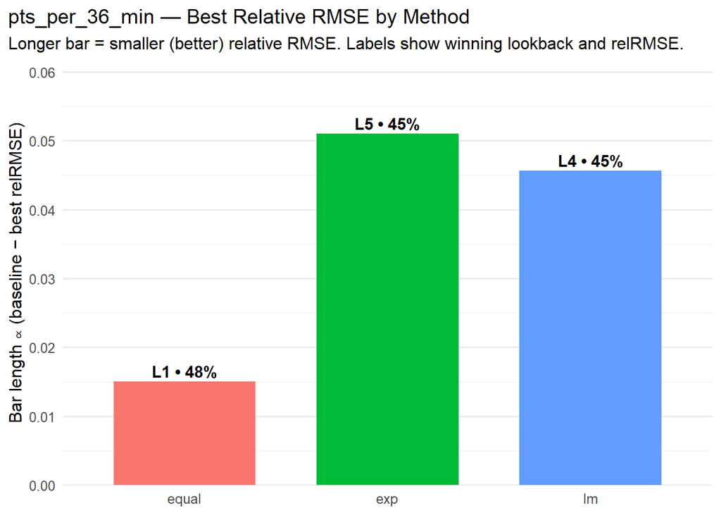

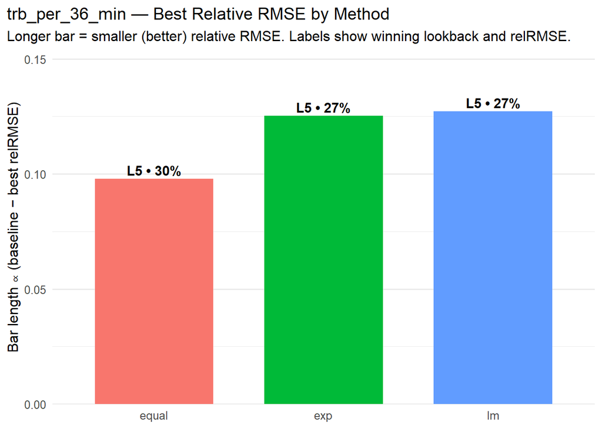

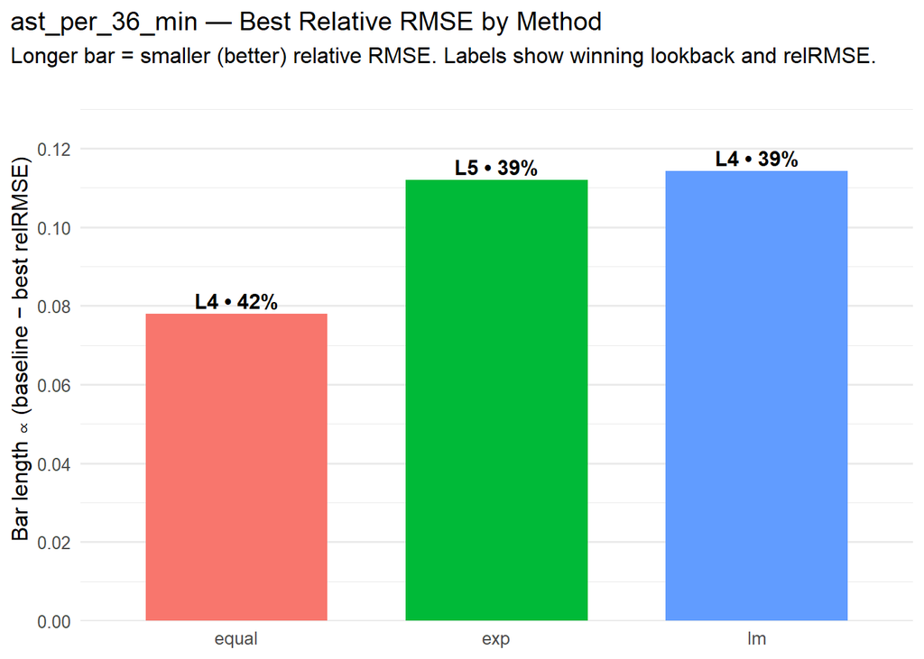

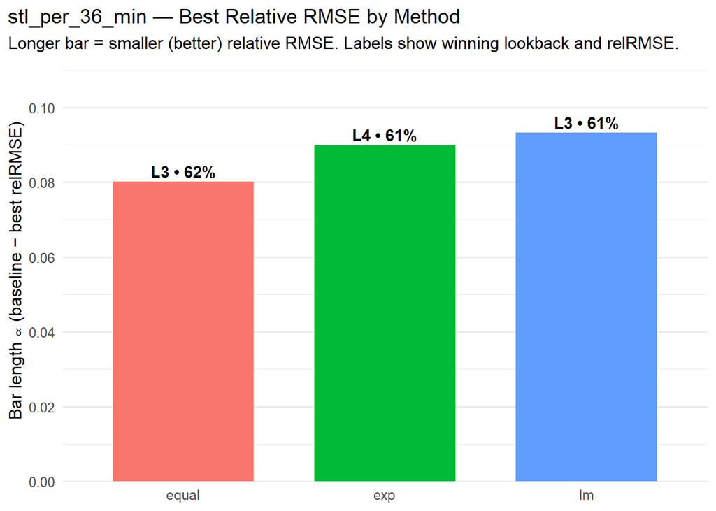

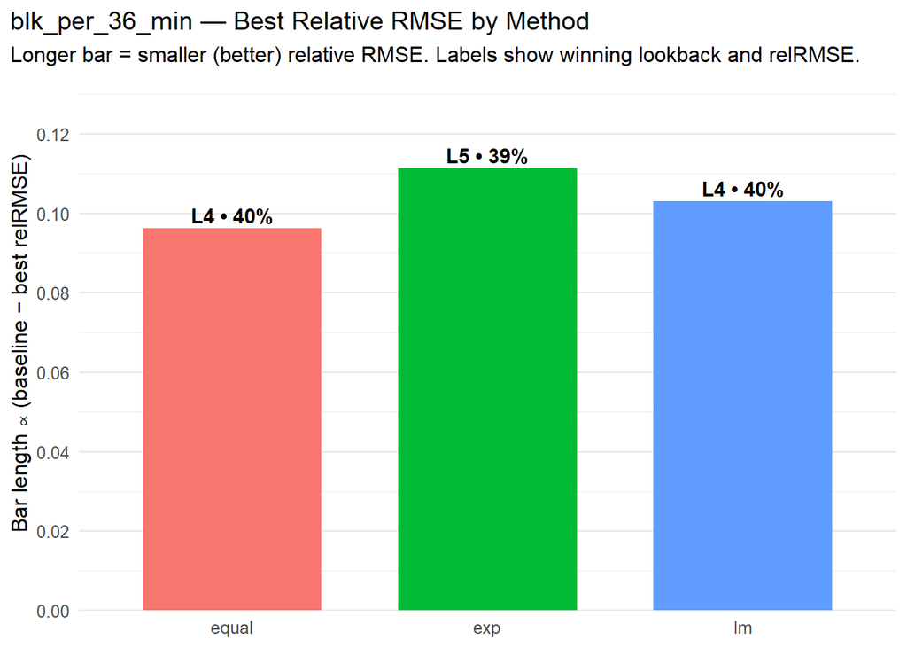

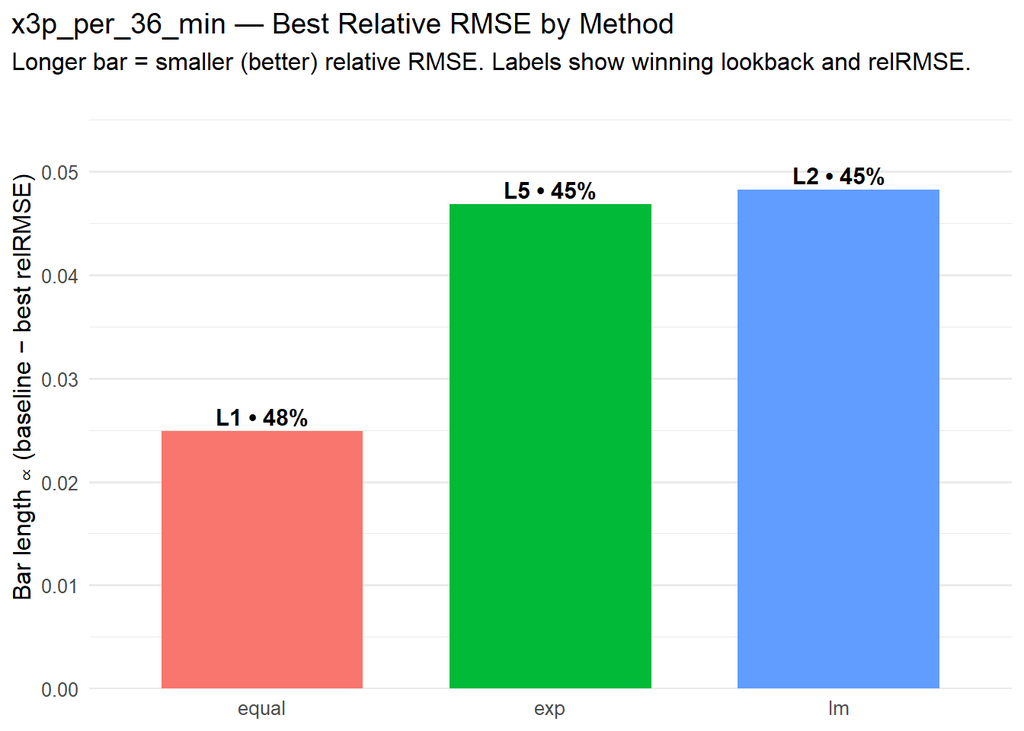

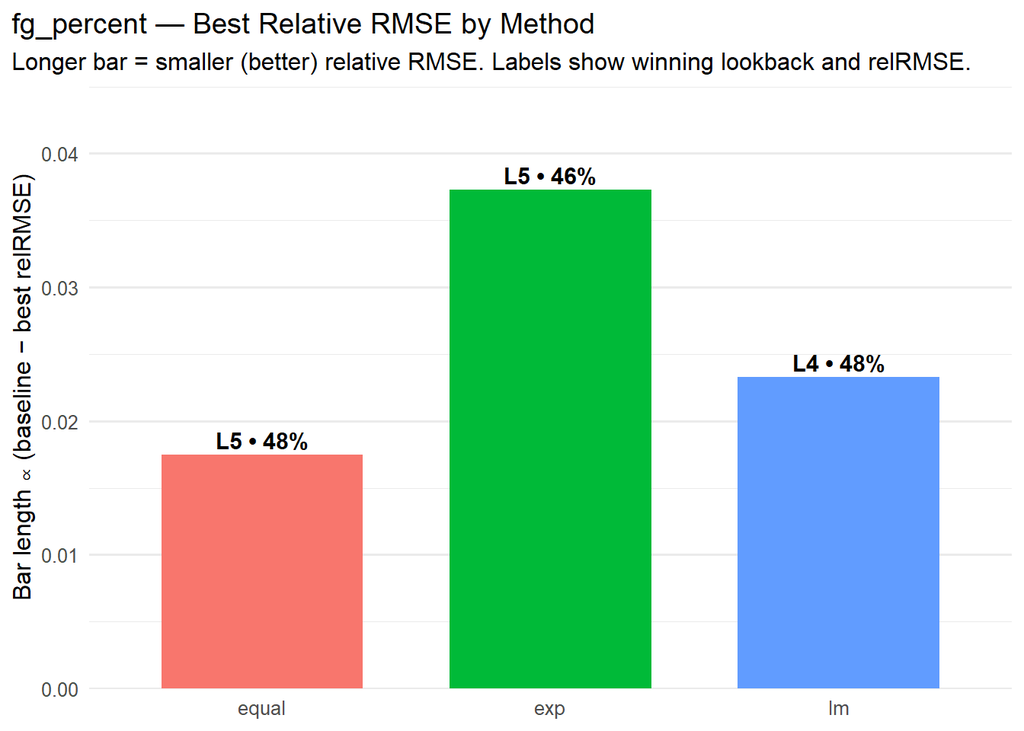

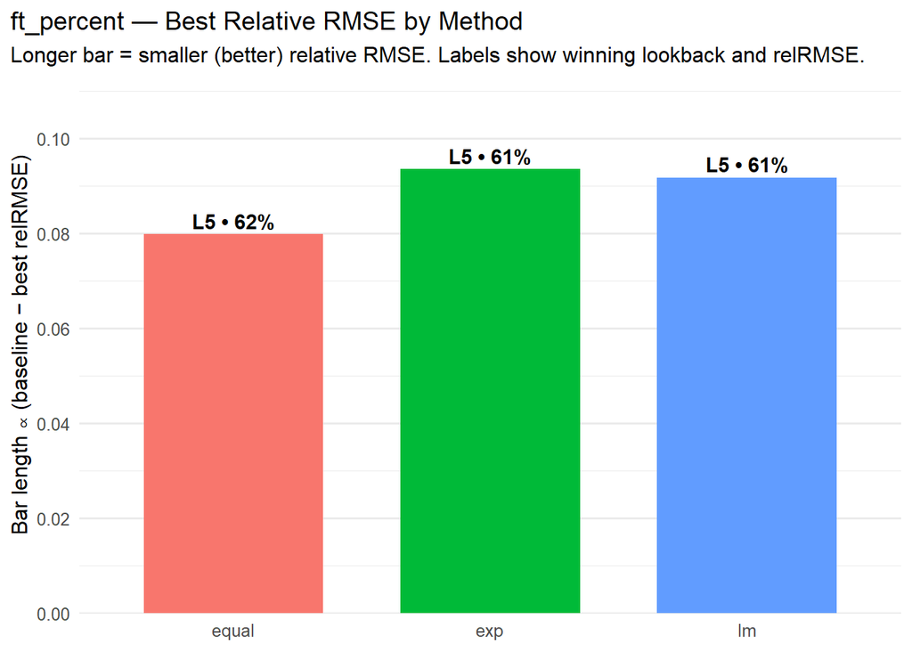

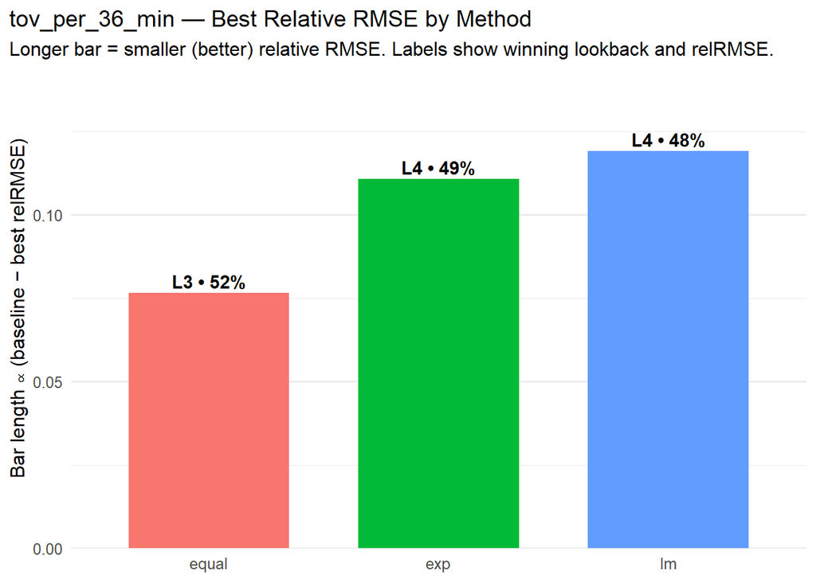

```r
library(dplyr)
library(ggplot2)
library(scales)
library(stringr)
library(tidyr)
library(purrr)

# Helper: pretty label for a stat key
lab_for_stat <- function(stat_key) {
  if (exists("stat_labs") && is.list(stat_labs) && stat_key %in% names(stat_labs)) {
    stat_labs[[stat_key]]
  } else stat_key
}

# --- Reducer: best per method for a given stat, from all_results ---
get_df_best <- function(target_stat) {
  stopifnot(all(c("stat","k","method","rel_rmse") %in% names(all_results)))
  all_results %>%
    filter(stat == target_stat, is.finite(rel_rmse)) %>%
    group_by(method) %>%
    summarise(
      best_rel_rmse = min(rel_rmse, na.rm = TRUE),
      best_k        = k[which.min(rel_rmse)][1],
      .groups = "drop"
    ) %>%
    mutate(method = factor(method, levels = c("equal","exp","lm")))
}

# --- Plot function: bars longer when RMSE is smaller (bars grow from bottom) ---
plot_best_rel_rmse_by_method <- function(target_stat, save = FALSE, out_dir = "output",
                                         width = 6, height = 4, dpi = 150) {
  df_best <- get_df_best(target_stat)

  # Fill any missing methods with NA so the x-axis keeps all three categories
  all_methods <- tibble(method = factor(c("equal","exp","lm"), levels = c("equal","exp","lm")))
  df_best <- all_methods %>% left_join(df_best, by = "method")

  # Compute a common band and a "bar length" so smaller RMSE -> longer bar
  worst    <- suppressWarnings(max(df_best$best_rel_rmse, na.rm = TRUE))
  best     <- suppressWarnings(min(df_best$best_rel_rmse, na.rm = TRUE))
  # guard for all-NA scenario
  if (!is.finite(worst)) worst <- 1
  if (!is.finite(best))  best  <- 0.2

  y_bottom <- ceiling(worst * 10) / 10      # round *up* to next 0.1
  y_top    <- floor(best  * 10) / 10        # round *down* to prev 0.1
  if (!is.finite(y_top) || y_top >= y_bottom) y_top <- max(best - 0.02, 0)

  # Bar length = how much better than the "worst band bottom" the method is
  df_best <- df_best %>%
    mutate(
      lab_k    = ifelse(is.na(best_k), "", paste0("L", best_k)),
      lab_rmse = ifelse(is.na(best_rel_rmse), "", percent(best_rel_rmse, accuracy = 1)),
      bar_len  = pmax(y_bottom - best_rel_rmse, 0)  # longer = smaller RMSE
    )

  title_txt <- paste0(lab_for_stat(target_stat), " — Best Relative RMSE by Method")

  p <- ggplot(df_best, aes(x = method, y = bar_len, fill = method)) +
    geom_col(width = 0.7, show.legend = FALSE, na.rm = TRUE) +
    # put the actual RMSE text slightly above the bar
    geom_text(aes(label = ifelse(lab_k == "", lab_rmse, paste0(lab_k, " • ", lab_rmse))),
              vjust = -0.35, size = 4, fontface = "bold", na.rm = TRUE) +
    # Y shows "longer is better"; annotate the scale meaning
    scale_y_continuous(
      limits = c(0, max(df_best$bar_len, na.rm = TRUE) * 1.15),
      expand = expansion(mult = c(0, 0.05)),
      breaks = pretty
    ) +
    labs(
      title = title_txt,
      subtitle = "Longer bar = smaller (better) relative RMSE. Labels show winning lookback and relRMSE.",
      x = NULL,
      y = "Bar length ∝ (baseline − best relRMSE)"
    ) +
    theme_minimal(base_size = 12) +
    theme(
      panel.grid.major.x = element_blank(),
      plot.title.position = "plot"
    )

  if (isTRUE(save)) {
    if (!dir.exists(out_dir)) dir.create(out_dir, recursive = TRUE)
    file_safe <- str_replace_all(target_stat, "[^A-Za-z0-9_]+", "_")
    out_path <- file.path(out_dir, paste0("relRMSE_", file_safe, ".png"))
    ggsave(out_path, p, width = width, height = height, dpi = dpi)
    message("Saved: ", out_path)
  }

  p
}

# --- Display one example interactively in the knitted HTML ---
# plot_best_rel_rmse_by_method("pts_per_36_min", save = FALSE)

# --- Display & save one figure per stat ---
# (Each plot will appear in the HTML and also be written to /output)
invisible(lapply(stats_vec, function(s) {
  p <- plot_best_rel_rmse_by_method(s, save = TRUE, out_dir = "output")
  print(p)  # ensures the plot is displayed in the knitted HTML
}))
```

# 11 Predictability Summary Visualization

This final visualization ranks all nine modeled statistics by predictability, measured through each stat’s best relative RMSE (lower is better). Each bar represents the optimal combination of method and lookback window that achieved the lowest error during the historical evaluation.

**Purpose**

- To summarize which player statistics are most consistently predictable from past performance.
- To illustrate the gap in year-to-year stability between different skill types (e.g., volume stats like rebounds vs. efficiency stats like free-throw %).
- To highlight the methods that proved most effective for each metric (color-coded by weighting method).

**Interpretation**

- Longer bars indicate higher predictability (smaller relative RMSE).
- Labels on each bar specify the winning method, lookback length, and achieved relative RMSE.
- All counting statistics are normalized per 36 minutes, ensuring fair comparisons across players and seasons.

## 11.1 TLDR

In short, this figure makes it easy to see which on-court metrics tend to persist most reliably year-to-year under optimal modeling conditions.

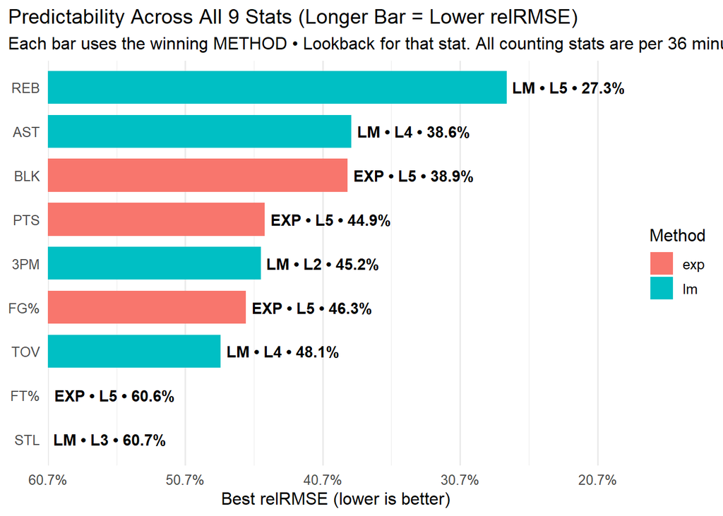

```r
library(dplyr)
library(ggplot2)
library(scales)

stopifnot(
exists("all_results"),
all(c("stat","method","k","rel_rmse") %in% names(all_results)),
exists("stats_vec")
)

# 1) Winner (lowest relRMSE) per stat across all methods/lookbacks

winners_per_stat <- all_results %>%
filter(is.finite(rel_rmse), stat %in% stats_vec) %>%
group_by(stat) %>%
slice_min(rel_rmse, n = 1, with_ties = FALSE) %>%
ungroup()

# 2) Short display labels

short_lab <- c(
"pts_per_36_min" = "PTS",
"trb_per_36_min" = "REB",
"ast_per_36_min" = "AST",
"stl_per_36_min" = "STL",
"x3p_per_36_min" = "3PM",
"tov_per_36_min" = "TOV",
"blk_per_36_min" = "BLK",
"fg_percent"     = "FG%",
"ft_percent"     = "FT%"
)

plot_df <- winners_per_stat %>%
mutate(
stat_label = short_lab[stat],
stat_label = factor(stat_label)  # we'll order next
) %>%
arrange(rel_rmse) %>%
mutate(stat_label = factor(stat_label, levels = rev(unique(stat_label))))

# 3) Convert to "longer = better" bar lengths via a baseline

baseline <- max(plot_df$rel_rmse, na.rm = TRUE)
plot_df <- plot_df %>% mutate(bar_len = pmax(baseline - rel_rmse, 0))

# Helper: bottom-axis breaks (on bar_len scale), labeled as relRMSE

mk_breaks <- function(x) pretty(x, n = 5)

p_all9_clean <- ggplot(plot_df, aes(x = stat_label, y = bar_len, fill = method)) +
geom_col(width = 0.75, show.legend = TRUE) +
geom_text(
aes(label = paste0(toupper(method), " • L", k, " • ", percent(rel_rmse, accuracy = 0.1))),
hjust = -0.05, size = 3.8, fontface = "bold"
) +
coord_flip() +
scale_y_continuous(
limits = c(0, max(plot_df$bar_len, na.rm = TRUE) * 1.12),
breaks = mk_breaks,
labels = function(b) percent(baseline - b, accuracy = 0.1),  # show actual relRMSE at bottom
expand = expansion(mult = c(0, 0.12)),
name = "Best relRMSE (lower is better)"
) +
labs(
title = "Predictability Across All 9 Stats (Longer Bar = Lower relRMSE)",
subtitle = "Each bar uses the winning METHOD • Lookback for that stat. All counting stats are per 36 minutes.",
x = NULL,
fill = "Method"
) +
theme_minimal(base_size = 12) +
theme(
panel.grid.major.y = element_blank(),
plot.title.position = "plot"
)

print(p_all9_clean)
```

```r
# Optional: save to /output

if (!dir.exists("output")) dir.create("output", recursive = TRUE)
ggsave(file.path("output", "all9_predictability_clean.png"),
p_all9_clean, width = 8.5, height = 5.25, dpi = 150)
```